# Introduction to Text Analysis

**Garren Gaut with contributions from Avishek Kumar**

- Data Source
- Preprocess
- Supervised Learning
- Unsupervised Learning
- Dimensionality Reduction

# Introduction

Text Analysis is used for summarizing or extracting useful information from large amounts of unstructured text. Text analysis encompases a large array of tasks:

[figure not shown]

- **Searches and information retrieval**: Help find relevant information in large databases such as a systematic literature review.
- **Clustering**: Text clustering is organizing text documents into groups that share properties such as theme, author, or type of document.
- **Dimensionality Reduction**: Techniques such as topic modeling can summarize a large corpus of text by representing documents as mixtures of topics.
- **Text Summarization**: Create category-sensitive text summaries of a large corpus of text.
- **Machine Translation**: Translate from one language to another.

In this tutorial we are going to analyze reddit posts from May 2015 in order to classify which subreddit a post origniated from and also do topic modeling to categorize posts.

## Demos

- [Stanford NLP](http://nlp.stanford.edu:8080/corenlp/process)
- [Illinois Cognitive Computation Group](http://cogcomp.cs.illinois.edu/page/demos/)
- [Event Search](http://eventregistry.org/searchEvents)

## Why is Language Analysis Hard?

- Ambiguity of Language
- Commonsense knowledge is typically omitted from social communications
- Abduction
- Language is dynamic
- Symbol grounding

## How do we represent a word?

### One-hot Encoding

`[0,0,0,...,0,1,0,...,0]`

### Distributed Representation

`[0.34, 0.51,...,0.49, 0.56, 0.72]`

## How do we represent a document?

### Bag-of-words

A bag of words is created by summing the one-hot encodings for all words in a document.

[figure not shown]

### Document Embedding

Document embeddings can be created by averaging over word embeddings. This assumes that words and document are 'occupying' the same semantic vector space.

## Glossary of Terms

- **Document Classification**: Predicting which class label belongs to a document (in this tutorial comments are documents).
- **LDA**: LDA (latent Dirichlet allocation) is a type of probabilistic model commonly used for topic modelling.
- **Stemming**: Stemming is a type of text normalization where words that have different forms but their essential meaning are normalized to the original dictionary form of a word. For example "go," "went," and "goes" all stem from the lemma "go."
- **Stop Words**: Stop words are words that have little semantic meaning like prepositions, articles and common nouns. They can often be ingnored.
- **TFIDF**: TFIDF (Term frequency-inverse document frequency) is an example of feature enginnering where the most important words are extracted by taking account their frequency in documents and the entire corpus of documents as a whole.
- **Tokenize**: Tokenization is the process by which text is sepearated into meaningful terms or phrases. For instance, separating sentences using punctuation.
- **Topic Modeling**: Topic modeling is an unsupervised learning method where groups of co-occuring words are clustered into topics. Typically, the words in a a cluster should be related and make sense (e.g, boat, ship, captain). Individual documents will then fall into multiple topics.
- **Word (type) vs word token**: In text analysis, *word (type)* refers to a unique set of characters. A *word token* is any occurance of a *word (type)*. For example, the sentence 'Oh boy, that boy is impressive!' contains 6 *word tokens*, but only 5 *word (types)*.

# Text Preprocessing

- Cleaning & Tokenization
- Stop Word Removal
- Normalization: Stemming & Lemmatization
- N-grams

## Text Processing Example

**Original Sentence**  
`Dude! I’m dying to go surfing. Let’s shred the gnar!`

**Clearning and Tokenizing**  
`[dude,im,dying,to,go,surfing,lets,shred,the,gnar]`

**Stop Word Removal**  
`[dying,surfing,shred,gnar]`

**Stemming and Lemmatization**  
`[dy,surf,shred,gnar] [die,surf,shred,gnar]`

**N-grams**  
`[die,die_surf,surf,surf_shred,shred,shred_gnar,gnar]`

**N-grams using POS**  
`[die,surf,shred,shred_gnar,gnar]`

# Text Processing In Scikit Learn

[figure not shown]

### Import Packages and Utility Functions

```python
%pylab inline
import nltk
import ujson
import re
import time

from sklearn.feature_extraction.text import CountVectorizer, TfidfTransformer
from sklearn.decomposition import LatentDirichletAllocation
from sklearn.linear_model import LogisticRegression
from sklearn.metrics import precision_recall_curve, roc_auc_score, roc_curve, auc
from sklearn.metrics.pairwise import euclidean_distances, cosine_distances, cosine_similarity
from sklearn import preprocessing
from sklearn.cluster import AgglomerativeClustering, spectral_clustering
from collections import Counter, OrderedDict
from nltk.corpus import stopwords
from nltk import SnowballStemmer

nltk.download('stopwords') # download the latest stopwords
```

```
True
```

```python
def load_reddit(fname, ls_subreddits=[], MIN_CHAR=30):
    """
    Loads Reddit Comments from a json file based on
    whether they are in the selected subreddits and
    have more than the MIN_CHARACTERS

    Parameters
    ----------
    fname: str
        filename
    ls_subreddits: ls[str]
        list of subreddits to select from
    MIN_CHAR: int
        minimum number of characters necessary to select
        a comment

    Returns
    -------
    corpus: ls[str]
        list of selected reddit comments
    subreddit_id: array[int]
        np.array of indices that match with the ls_subreddit
        index
    """
    corpus = []
    subreddit_id = []
    with open(fname, 'r') as infile:
        for line in infile:
            dict_reddit_post =  ujson.loads(line)
            subreddit = dict_reddit_post['subreddit']
            n_characters = len( dict_reddit_post['body'] )

            if ls_subreddits: # check that the list is not empty
                in_ls_subreddits = subreddit in ls_subreddits
            else:
                in_ls_subreddits = True

            grter_than_min = n_characters > MIN_CHAR

            if ( grter_than_min and in_ls_subreddits ):
                corpus.append(dict_reddit_post['body'])
                subreddit_id.append(subreddit)

    return np.array(corpus), np.array(subreddit_id)
```

```python
def plot_roc(y_true, y_score):
    """
    Plots the precision and recall as a function
    of the percent of data for which we calculate
    precision and recall

    Parameters
    ----------
    ytrue:

    yprob_:

    model_name:

    """
    # Compute micro-average ROC curve and ROC area
    fpr, tpr, _ = roc_curve(y_true, y_score)
    roc_auc = roc_auc_score( y_true, y_score)


    plt.figure()
    lw = 2
    plt.plot(fpr, tpr, color='darkorange',
         lw=lw, label='ROC curve (area = %0.2f)' % roc_auc)
    plt.plot([0, 1], [0, 1], color='navy', lw=lw, linestyle='--')
    plt.xlim([0.0, 1.0])
    plt.ylim([0.0, 1.05])
    plt.xlabel('False Positive Rate')
    plt.ylabel('True Positive Rate')
    plt.title('ROC Curve')
    plt.legend(loc="lower right")
    plt.show()
```

# Load and Preprocess Data

### Data Source: Reddit Comments from May 2015 in JSON format

For the superivised learning portion of the tutorial we will being attempting to classify whether reddit comments have come from /r/SucideWatch or /r/depression. These two subreddits are somewhat similiar so it poses a non-trivial challenge for a classifier.

```python
# grab data from the following subreddits
ls_subreddits = ['SuicideWatch', 'depression']
[corpus, subreddit_id] = load_reddit('./data/RC_2015-05.json', ls_subreddits, MIN_CHAR=30)

# count the number of comments in each subreddit
Counter(subreddit_id)
```

```
Counter({'SuicideWatch': 12609, 'depression': 24683})
```

## Preprocess the data

In order to quantify our text, we will have to remove characters that aren't parts of words.

```python
# create an expression to remove from data
RE_PREPROCESS = re.compile(r""" \W + # one or more nonword characters
                                |    # the or operator
                                \d+  # the decimal point""", re.VERBOSE)

# remove anything matching RE_PREPROCESS and make lowercase
processed_corpus = np.array( [ re.sub(RE_PREPROCESS, ' ', comment).lower() for comment in corpus] )
#processed_corpus2 = np.array( [ re.sub(RE_PREPROCESS2, ' ', comment).lower() for comment in corpus] )

# check out original and preprocessed data
num_comment_to_view = 0
for i in range(0, num_comment_to_view):
    print("Original: subreddit: {}, comment: {}".format(subreddit_id[i],corpus[i]))
    print()
    print("Processed: subreddit: {}, comment: {}".format(subreddit_id[i],processed_corpus[i]))

    print('\n\n')
```

### Activity 1:

**10 mins**

Write your own preprocessing routine that removes **only happy and sad emojis** from each comment in the corpus. Write a loop that prints comments `[1788, 2360, 9679, 18096]` to check that your choice of regular expression preprocess the text as you intended. [Python regular expression documentation](https://docs.python.org/2/library/re.html) will be helpful.

```python
# ANSWER
comments_to_check = [1788, 2360, 9679, 18096]

RE_PREPROCESS_EMOJI = re.compile(r'(:\))|(:\()')

emojiless_corpus = np.array( [ re.sub(RE_PREPROCESS_EMOJI, ' ', comment) for comment in corpus] )
for i in comments_to_check:
    print("\nComment {}:\n \n{}\n{}".format(i, corpus[i], emojiless_corpus[i]))
```

```
Comment 1788:

:/ this loneliness must be so hard then...I do hope you'll think about calling a friend if these feelings get stronger.  I don't want you to be scared.
:/ this loneliness must be so hard then...I do hope you'll think about calling a friend if these feelings get stronger.  I don't want you to be scared.

Comment 2360:

:( You need to call someone...I had a panic attack right before I swallowed around 10 pills and saw the fucking police coming up the steps for me...I know that feeling.

You can do serious damage and please don't take anymore pills. I care about you. :)

~LG
  You need to call someone...I had a panic attack right before I swallowed around 10 pills and saw the fucking police coming up the steps for me...I know that feeling.

You can do serious damage and please don't take anymore pills. I care about you.

~LG

Comment 9679:

:| seriously? I wanted to get into building this pc as a **hobby**, something to get myself interested in. I already go for jogs and stuff, take pills, but I often feel I'm not doing anything productive with my life
:| seriously? I wanted to get into building this pc as a **hobby**, something to get myself interested in. I already go for jogs and stuff, take pills, but I often feel I'm not doing anything productive with my life

Comment 18096:

:) thank you, Im working on it for sure or at least trying to
  thank you, Im working on it for sure or at least trying to
```

# Comment Classification: Supervised Learning

In this section we are going to train a classifier to properly tag the original subreddit in which the comment appeared. First we split our data into a testing and training set using the first 80% of the data as the training set and the remaining 20% as the testing set.

## Create Training/Test Splits

```python
#split the data into training and testing sets.
#refactor this in the test train-split
train_set_size = int(0.8*len(subreddit_id))
train_idx = np.arange(0,train_set_size)
test_idx = np.arange(train_set_size, len(subreddit_id))

train_subreddit_id = subreddit_id[train_idx]
train_corpus = processed_corpus[train_idx]

test_subreddit_id = subreddit_id[test_idx]
test_processed_corpus = processed_corpus[test_idx]
test_corpus = corpus[test_idx]

print('Training Labels', Counter(subreddit_id[train_idx]))
print('Testing Labels', Counter((subreddit_id[test_idx])))
```

```
Training Labels Counter({'depression': 19382, 'SuicideWatch': 10451})
Testing Labels Counter({'depression': 5301, 'SuicideWatch': 2158})
```

## Tokenize and stem to create features

Now that we have the data and we have done a bit of preprocessing, we want to create features. We quantify words as **one-hot encodings** and create document word counts by summing encodings over words in a documents. Scikit-learn as a [CountVectorizer method](http://scikit-learn.org/stable/modules/generated/sklearn.feature_extraction.text.CountVectorizer.html) that makes this step simple.

We first create a vectorizer object that stores the frequency of words in each of the documents in a **document-term count matrix**. We will discard very high and low frequency words. For example, the words *the* or *for* may appear often throughout a corpus but contain very little semantic information. Conversely a document may contain obscure words that do not occur anywhere in else in the corpus which could cause models to overfit. These cases are managed by setting a threshold for the Min and Max Document Frequency(DF).

```python
# parameters for vectorizer
ANALYZER = "word" # unit of features are single words rather then phrases of words
STRIP_ACCENTS = 'unicode'
TOKENIZER = None
NGRAM_RANGE = (0,2) # Range for n-grams
MIN_DF = 0.01 # Exclude words that are contained in less that x percent of documents
MAX_DF = 0.8  # Exclude words that are contained in more than x percent of documents

vectorizer = CountVectorizer(analyzer=ANALYZER,
                            tokenizer=None, # alternatively tokenize_and_stem but it will be slower
                            ngram_range=NGRAM_RANGE,
                            stop_words = stopwords.words('english'),
                            strip_accents=STRIP_ACCENTS,
                            min_df = MIN_DF,
                            max_df = MAX_DF)
                            # could add 'token_pattern' argument to specify what denotes a token
```

**TFIDF (Term Frequency Inverse Document Frequency)** transforms a count matrix--what we created above--into a TFIDF represenation. This is done by reweighting words that occur throughout the entire corpus to a lower weight due to empirically being found to be less discriminative.

```python
NORM = None #turn on normalization flag
SMOOTH_IDF = True #prvents division by zero errors
SUBLINEAR_IDF = True #replace TF with 1 + log(TF)
USE_IDF = True #flag to control whether to use TFIDF

transformer = TfidfTransformer(norm = NORM,smooth_idf = SMOOTH_IDF,sublinear_tf = True)
```

```python
#get the bag-of-words from the vectorizer and
#then use TFIDF to limit the tokens found throughout the text
start_time = time.time()
train_bag_of_words = vectorizer.fit_transform( train_corpus )
test_bag_of_words = vectorizer.transform( test_processed_corpus )
if USE_IDF:
    train_tfidf = transformer.fit_transform(train_bag_of_words)
    test_tfidf = transformer.transform(test_bag_of_words)
features = vectorizer.get_feature_names()
print('Time Elapsed: {0:.2f}s'.format(
        time.time()-start_time))
```

```
Time Elapsed: 13.95s
```

### Activity 2:

**20 mins**

In text analysis, words are frequently **stemmed** or **lemmatized** in order to reduce the size of the vocubalary and treat words with similar semantic meaning as the same word. Stemming consists of removing parts of words to create a stem. For example, the word tokens `eat, eating, eatery, eaten, eater` would all be stemmed to the word `eat`. The CountVectorizer provides an easy way incorporate stemming into preprocessing via the *tokenizer* parameter which takes a function handle as an argument. For this activity, create a function to pass to the [CountVectorizer](http://scikit-learn.org/stable/modules/generated/sklearn.feature_extraction.text.CountVectorizer.html) that will stem all words in your corpora. Use the CountVectorizer with this function as an argument to preprocess the corpus (this may take some time). Store the result in a variable called `stemmed_corpus`. Below is an example of a stemmer from the nltk toolkit that will be helpful.

```python
from nltk import SnowballStemmer
stemmer = SnowballStemmer("english")
x = 'eating'
stemmer.stem(x)
```

[output not shown]

```python
# ANSWER
def tokenize_and_stem(comment, stemmer = stemmer):
    """
    Takes a reddit comment and stemmer as input
    and returns a list of stemmed words

    Parameters
    ----------
    comment: str
    stemmer: nltk stemmer object

    Returns
    -------
    stemmed_comment: ls[str]
        list of stemmed words
    """
    stemmed_comment = [stemmer.stem(word) for word in comment]
    return stemmed_comment

vectorizer_stem = CountVectorizer(analyzer=ANALYZER,
                            tokenizer=tokenize_and_stem, # alternatively tokenize_and_stem but it will be slower
                            ngram_range=NGRAM_RANGE,
                            stop_words = stopwords.words('english'),
                            strip_accents=STRIP_ACCENTS,
                            min_df = MIN_DF,
                            max_df = MAX_DF)

start_time = time.time()
train_bag_of_words_stem = vectorizer.fit_transform( train_corpus )
test_bag_of_words_stem = vectorizer.transform( test_corpus )
if USE_IDF:
    train_tfidf_stem = transformer.fit_transform(train_bag_of_words)
    test_tfidf_stem = transformer.transform(test_bag_of_words)
features_stem = vectorizer.get_feature_names()
print('Time Elapsed: {0:.2f}s'.format(
        time.time()-start_time))
```

[output not shown]

## Fit and Evaluate a Supervised Model

**Fit** We will fit a regularized logistic regression model that takes a comment as input and produces a subreddit classification (/r/SuicideWatch or /r/depression) as output.

### Regularized Logistic Regression

Regularized logistic regression solves the following optimization problem:

$$ \min_{\bf w}{\frac{1}{2}||{\bf w}||_d + C \sum_{i=1}^{N}{\textrm{log}(1+e^{−{y_i}{\bf w}^{T}x_i})} }$$

where $(x_i, y_i)$ are the features and label for the $i$th datapoint, $\bf w$ is a vector of model coefficients (or weights), $C$ is a regularization parameter, and $d$ specifies a norm (usually l1 or l2). The l1 norm will force coefficients that are not useful for class dicrimination to zero. The loss function $\textrm{log}(1+e^{−{y_i}{\bf w}^{T}x_i})$ is derived from a probabilistic model and is referred to as the logistic loss.

```python
# Fit a regularized logistic regression model
clf = LogisticRegression(penalty='l2')
mdl = clf.fit(train_tfidf,
              subreddit_id_binary[train_idx])
y_score = mdl.predict_proba( test_tfidf )
```

**Evaluate** To evalute how our classifer performed we find the Area Under the Curve (AUC) of a Receiver Operating Characteristic (ROC) curve. The ROC curve plots the true positive rate versus the false positive rate for each threshold.

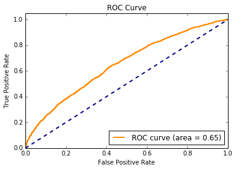

```python
plot_roc(subreddit_id_binary[test_idx], y_score[:,1])
```

## Feature Importance

### Activity 3

**20mins**

To understand what the model is doing, we want to see which features make the model more likely to classify a comment as a certain class. The CountVectorizer provides a list of features (using the `get_feature_names()` method) and model coefficients can be found in using the `coef_` method. For this activity, make a sorted list or dictionary of features and their importances (i.e., the corresponding coefficient value). Print the 5 most important features for classifying a comment as each of our class labels, SuicideWatch and depression.

```python
# ANSWER
coef = mdl.coef_.ravel()

dict_feature_importances = dict( zip(features, coef) )
orddict_feature_importances = OrderedDict(
                                sorted(dict_feature_importances.items(), key=lambda x: x[1]) )

ls_sorted_features  = list(orddict_feature_importances.keys())

num_features = 5
suicidewatch_features = ls_sorted_features[:5] #SuicideWatch
depression_features = ls_sorted_features[-5:] #depression
print('SuicideWatch: ',suicidewatch_features)
print('depression: ', depression_features)
```

```
SuicideWatch:  ['suicide', 'please', 'talked', 'suicidal', 'hospital']
depression:  ['helps', 'psychiatrist', 'depressed', 'effects', 'depression']
```

## Examine Confident Predictions

We want to see which comments the model scores as highly probable to belong to either class. This step can help to look for patterns in model classification and to check for any obvious errors. The predict probability refers to the probablity of a comment belonging to the depression subreddit. Therefore, comments belonging to the SucideWatch subreddit will have a low probablity.

```python
# maybe do something with this crazy indexing: this is python not C!
num_comments = 5
subreddit0_comment_idx = y_score[:,1].argsort()[:num_comments] #SuicideWatch
subreddit1_comment_idx = y_score[:,1].argsort()[-num_comments:] #depression

# convert back to the indices of the original dataset
top_comments_testing_set_idx = np.concatenate([subreddit0_comment_idx,
                                               subreddit1_comment_idx])
```

```python
# these are the 5 comments the model is most sure of
for i in top_comments_testing_set_idx:
    print(
        u"""{}:{}\n---\n{}\n===""".format(test_subreddit_id[i],
                                          y_score[i,1],
                                          test_corpus[i]))
```

```
SuicideWatch:0.009617024344665628
---
It sounds like you're exhausted on many levels and are losing hope or have lost hope. I'm so sorry.

For what it's worth, it's striking that you give equal weight in your post to your personal struggles and your existential despair at the state of the world. That's pretty remarkable - it speaks to your empathy. You are not worthless. I think that you want to help people. You say that you don't even…

I know that I can't imagine the added pain of being trans in a hostile world, though some of this, I get. I'm queer too and not in a good situation right now and it sounds like you've got something eating disordered type stuff going on - that certainly makes the world a harder place to live in. Ther…
===
SuicideWatch:0.022749824384601065
---
If life were just, heartbreak would kill you on the spot. It hurts so bad and so deep in places only that person could touch. And when the hurt is gone there is a big hole for a long time that can get filled up any number of ways. Some people fill it with anger - anger about a lot of things; their l…

I had my heart broken so badly I wanted to die a little over a year ago. I said "fuck it" to the life I thought I was going to lead (but couldn't because of the break up) and did something absolutely crazy. I sailed across the Indian Ocean. Trust me, nothing makes you dig deeper down into yourself a…

I hope this didn't seem trite. I really empathize with your pain. Please let me know if you need someone to talk to. -- you can do anything in the world when you have nothing to lose.
===
SuicideWatch:0.028515195298273954
---
The reason why hotlines are the norm is that a lot of friends and family, even if they have all the love in the world, just aren't emotionally equipped to deal with our thoughts of suicide.  So I think you're being wise and realistic to put some thought into how you present this to your family.

I also answer a hotline IRL and one of the things we end up doing quite often is helping people figure out how to break things to their families.  We also always help people work out a "Plan B" for what to do if telling the family doesn't go well.  So talking to your local or national hotline first …

Either way, I think we might be able to help you more here in framing the conversation if you could tell us a bit more about yourself and your family, how long you've been feeling this way, and what your relationship's been like up to this point.

It's never an easy conversation to have, no matter how well prepared we are, but it sounds like you need to have it soon.  You said that you've been really struggling with thoughts of suicide for a couple of weeks - were there any changes in your life or events that precipitated this?

Hugs.
===
SuicideWatch:0.028971064279539174
---
Hey OP, just letting you know I'm here, so I'll just carry over what you posted in your last post over here. I'll respond to that a little later, please give me a little moment.

&gt; Original Post:
This is my little way of venting and hopefully making myself feel better. Sort of my way of telling the whole world how I feel but not necessarily anyone will read it, if that makes sense. Well it does to me. The best way to describe it is that I prefer to have it here on reddit with the possibility…

&gt; In short I want to die. That's it really. I just want to stop living. Not because I'm depressed from sadness, but because I'm tired. I'm only 19 years old and I feel like I'm 80. In high school teachers, counselors, etc. always use to ask my peers and I where we saw ourselves in ten years. I ne…
===
SuicideWatch:0.029879756139131398
---
I am sorry that you want to kill yourself. This is not a place to ask for methods, but let me tell you one thing - there is no fail safe method to kill yourself. Anything you would do, there's no guarantee that you wouldn't end up in some really fucked up state. Trust me, I researched it a lot in my…
```

[output cut: 129 more lines]

```
QualiaSoup's [video on a logical basis for morality](https://www.youtube.com/watch?v=T7xt5LtgsxQ&amp;list=SP0EFCB22DFCD4F2E7) is quite helpful in divorcing the notion of morality from your own personal feelings as is [Sam Harris' TED talk on the subject](https://www.youtube.com/watch?v=Hj9oB4zpHww).

I'd also recommend Sam's video on [free will](https://www.youtube.com/watch?v=pCofmZlC72g) as it outlines some pretty interesting points.

[Phil Hellenes](https://www.youtube.com/user/philhellenes) has some food for thought/secular inspirational videos and is well worth checking out.

[This](http://youtu.be/0qDtHdloK44) is a poem titled "Shake The Dust" written and performed by "Anis Mojgani" at the 2010 "Heavy and Light" concert/poetry slam hosted by the suicide/self-harm prevention advocacy group "To Write Love On Her Arms" that I've found particularly empowering when I'm strug…
- - -

Once again, I derive a lot of my positions from very secular sources (because they're equally available to anyone regardless of belief system) so if you're religious they might put you off a bit.

Just remember: You're not alone, you're not evil and you're not doomed.

We're all here for you so talk to us.
===
```

# Comment Similarity and Clustering: Unsupervised Learning

The first step in grouping documents is to define a measure of similarity between documents. A common measure of similarity for non-text data is euclidean distance. However the euclidean distance between document-term vectors ignore the length of the document. For example, if document one consists of a single sentence and document two consists of that same sentence repeated multiple times, the euclidean distance will be nonzero. To overcome this issue documents are often compared using cosine similarity, which measures the angle between two count vectors.

### Cosine Similarity

The cosine similarity between two vectors ${\bf x}$ and ${\bf y}$ is defined as:

$$\textrm{cos}({\bf x},{\bf y}) = \frac{{\bf x} \bullet {\bf y}}{||\bf x|| \; || \bf y ||}$$

.

The common conceptual interpretations of the cosine similarity is the angle between two vectors. In text analysis each document is represented as a point in a $V$-dimensional, where $V$ is the size of the vocabulary. Thus by normalizing we are looking at the percent of a document that each word compromises instead of the raw counts of word tokens.

Below is an example illustrating why we use cosine distance. The example computes the euclidean and cosine distances between repeated sentences.

```python
sentences = ['The girl went to the store',
             'The girl went to the store. The girl went to the store',
             'The girl went to the store. The girl went to the store. The girl went to the store']

vectorizer_sim = CountVectorizer(analyzer=ANALYZER,
                            tokenizer=None, # alternatively tokenize_and_stem but it will be slower
                            ngram_range=(0,1)
                            )

sentence_count = vectorizer_sim.fit_transform( sentences )


euclidean_distance = euclidean_distances(sentence_count, Y = None)# sentence_count, Y=None, dense_output=True, 'l2')
cosine_distance = cosine_distances(sentence_count, Y=None )

print("Euclidean Distance\n", euclidean_distance.round(2))
print("\nCosine Distance\n", cosine_distance.round(2))
```

```
Euclidean Distance
 [[ 0.    2.83  5.66]
 [ 2.83  0.    2.83]
 [ 5.66  2.83  0.  ]]

Cosine Distance
 [[ 0.  0.  0.]
 [ 0.  0.  0.]
 [ 0.  0. -0.]]
```

```python
num_comments = 1000
bag_of_words = vectorizer.fit_transform( processed_corpus[0:(num_comments-1)] )
```

```python
#cluster = AgglomerativeClustering(n_clusters = 10, affinity="cosine", linkage ="average")
#cluster.fit(bag_of_words.toarray())
#labels = cluster.labels__

start_time = time.time()

# calculate cosine similarity and fit clustering algorithm
cosine_similarity = cosine_similarity(bag_of_words, Y=None )
labels = spectral_clustering(affinity=cosine_distance, n_clusters = 4)

print('Time Elapsed: {0:.2f}s'.format(
        time.time()-start_time))

label_counter = Counter(labels)
print(label_counter)
```

[output not shown]

```python
# examine the comments that fall in each group
# what defines each group?
for key, value in label_counter.items():
    count = 0
    print("\n-------Group{}-------\n\n".format(key))
    for i in range(0, num_comments-1):
        if (labels[i] == key) & (count < num_comments_to_view):
            print("Comment {0}: {1}\n".format(i, corpus[i]))
            #print("Comment {0}: {1}\n".format(i, processed_corpus[i]))
            count += 1
```

```
-------Group0-------


Comment 5: Ah. Well, sometimes just him listening can be enough. Just so long as he doesn't tell you to snap out of it or anything like that. Maybe you can also research support groups in your area. Try and find as many resources as you can.

Comment 15: I'm sure you're a very pretty young girl.  Please don't let the tauntings of small-minded people scar you.
Just endure for a little while longer.  These things improve greatly in a few years.

Comment 16: This is a reply to OP and also /u/strincheese13 and /u/elleundomiel.

It may seem like it, but please believe me that your future is far from ruined because of a bad year or two in school.  Sure, it may make things a bit tougher in some respects, but you are far from doomed because of it. For the vast majority of careers, especially that don't require post-graduate ed…

Comment 27: [It's a very difficult topic to understand without first hand experience.] (http://i.huffpost.com/gen/2271298/thumbs/o-ROBOT-HUGS-570.jpg?6)

Comment 29: I've been in a sexless, loveless marriage for 12 years and I wish I could just die. I have ptsd from being raped as a teenager. I have suffered many breakdowns. Quit driving, quit working. I've become a complete shut in. I've just now starting driving again. I want to leave my husband, b…


-------Group1-------


Comment 1: Just logged back onto my alt. Thank you. That means a lot to me, I know I'm late and all but ... thanks.

Comment 7: We aren't friends. We don't dislike each other we just keep it professional. I could easily be replaced and life would go on so I guess i don't see why it would be a bad thing.

Comment 8: As someone a bit older, I can say this with some authority - pretty much everyone is attractive to some chunk of people.  One thing that happens in school is that people are afraid to appear different, so if they have tastes that lie outside the mainstream, they may very well be afraid to…

It sucks that you're on the wrong end of that sort of thing right now, but it will change with time.  And hell, if you're still in school, your body hasn't even finished developing.  You might look far more like how you want to look in a few years.

Comment 13: Does a lot of what im going through apply to you as well?

Comment 34: I can relate. Apathy is the destroyer of progress. At least that's how I see it. That's the feeling I get. It's not a feeling of sadness. It's *nothing*. The feeling of emptiness and life's borders growing beyond your grasp. I 'cure' my feeling of inadequacy with alcohol (like right now)…

When it comes to motivation, I've found that no one will give it to you, but yourself. I hate that fact, but that's what it seems like. I have little of it myself, but the little I muster up for the absolutely essential shit all comes from myself. Use it sparingly and use it wisely.

(I have no idea if this is really helpful. It's my first time posting on this sub-reddit.)


-------Group2-------


```

[output cut: 32 more lines]

```
Reddit is unfortunately a site taken over by the opinions of about 4000 people. If you ever look at the controversial tab of a subreddit or even scrolling far enough down, you'll find those hidden treasures of good comments. I hope you will find those same kinds of good comments under this post as w…

Never be afraid to reply OP. I'll be expecting that orange envelope.

Comment 10: I'm in the exact same boat... Everyday I wake up with such a depressive mindset. I have absolutely no drive and I have no reason to get up in the mornings. I have no friends, no job and I only attend college 3 times a week.

Sometimes I have a sudden spurdge of happiness. Usually when I'm in a good mood I have my drive back, I want to do things. I want to make sure that I grasp onto my future and make a name for myself before its too late. I come up with all these plans on how I'm going to do this then booom depression …



It's so hard to actually have drive when you have nothing to motivate you. I have 0 irk friends. My days consist of talking to people online who really have no real impact on my real life.
I just can't handle it. My life right now is going nowhere, every day gets worse and worse, my grandparents who are basically my parents. They mean they world to me and it's so sad when I see them I know the time is getting closer and closer, their health is going down hill every day and it puts tea…
This post has gone out of hand. This is my feelings talking. I'm sorry if I've missed the objective of this post. I just needed somewhere to throw my emotions

Thank you I wish all the best for you xxx
```

# Topic Modeling: Dimensionality Reduction

In this portion of the tutorial we will be extracting topics in the form of commonly co-occuring words from the corpus of data. A topic model is a generative model of document creation used for automatic summarization of text into topics, or mixtures of words. While many variants exist (e.g., supervised, unsupervised, dynamic, hierarchical, structural), this tutorial will cover the standard topic model. The standard topic model makes three assumptions:

- Bag-of-words: semantic meaning can be extracted from word co-occurance
- Dimensionality reduction is essential to understanding semantic information
- Topics (lower dimensional units) can be expressed as a probability distribution over words

[figure not shown]

## Topic Model IO

### Input

Document term count matrix

### Output

**Topics**--the probability of each word being expressed in a given topic  
**Document Mixtures**--the probability of each topic being expressed in a document

[figure not shown]

## Example Topics

[figure not shown]

## Load and Preprocess Reddit Data

```python
start = time.time()
corpus_all, subreddit_id_all = load_reddit('./data/RC_2015-05.json',MIN_CHAR=250)
end = time.time()
print('Loading takes {0:2f}s'.format(end-start))
```

```
Loading takes 4.794395s
```

```python
# Get rid of punctuation and set to lowercase
start = time.time()
processed_corpus_all = [ re.sub( RE_PREPROCESS, ' ', comment).lower() for comment in corpus_all]

#tokenzie the words
bag_of_words_all = vectorizer.fit_transform( processed_corpus_all )
end = time.time()
#grab the features/vocabulary
features_all = vectorizer.get_feature_names()
print("Processing took {}s".format(end - start))
```

```
Processing took 29.07464623451233s
```

```python
print(Counter(subreddit_id_all), len(subreddit_id_all))
```

```
Counter({'depression': 12079, 'offmychest': 10661, 'stopdrinking': 6958, 'SuicideWatch': 6098, 'ADHD': 5674, 'GetMotivated': 4799, 'Anxiety': 4466, 'Meditation': 3608, 'stopsmoking': 1867, 'leaves': 1629, 'BPD': 1618, 'BipolarReddit': 1515, 'OpiatesRecovery': 1391, 'socialanxiety': 1221, 'StopGaming…
```

## Fit a Topic Model

To create our topics we will use Latent Dirichlet Allocation (LDA, i.e., the standard topic model). Both [scikit learn](http://scikit-learn.org/stable/modules/generated/sklearn.decomposition.LatentDirichletAllocation.html) and [gensim](https://radimrehurek.com/gensim/) provide software for fitting LDA. Both methods use [online variational inference](https://www.cs.princeton.edu/~blei/papers/HoffmanBleiBach2010b.pdf) to fit the model, but alternative methods such as [Gibbs sampling](https://people.cs.umass.edu/~wallach/courses/s11/cmpsci791ss/readings/steyvers06probabilistic.pdf) are also popular.

```python
# Options
N_TOPICS = 50
N_TOP_WORDS = 10

start = time.time()
lda = LatentDirichletAllocation( n_topics = N_TOPICS )
doctopic = lda.fit_transform( bag_of_words_all )
end = time.time()
print("Processing took {}s".format(end- start)) # takes ~72s for 1 file, ~445s for 5 files
```

```
Processing took 352.21460127830505s
```

## Display the top ten words for each topics

Qualitatively examining the topic output is the most common method for assessing fit of a topic model. Ideally, most topics will be interpretable. Topic interpretability tends to increase with the number of documents used during fitting.

```python
ls_keywords = []
for i,topic in enumerate(lda.components_):
    word_idx = np.argsort(topic)[::-1][:N_TOP_WORDS]
    keywords = ', '.join( features_all[i] for i in word_idx)
    ls_keywords.append(keywords)
    print(i, keywords)
```

```
0 read, normal, dont, loved, scared, follow, books, skills, found, nearly
1 brain, adhd, issues, use, attention, also, due, cause, part, several
2 job, money, thinking, stop, hours, using, fix, spend, jobs, straight
3 keep, body, mind, practice, simple, reasons, choose, going, helps, kept
4 pretty, school, really, much, high, reading, get, think, lot, end
5 family, us, book, bring, young, wait, interested, called, together, loss
6 http, com, www, http www, reddit, message, reddit com, www reddit, comments, please
7 good, luck, best, good luck, idea, great, recovery, addiction, another, choice
8 less, living, stress, full, knowing, difference, horrible, gave, moved, order
9 gt, amp, org, drugs, words, hang, wiki, research, history, amount
10 else, alone, anyone, others, answer, perhaps, yet, question, something, big
11 thanks, control, thank, told, feels, let, steps, appreciate, inside, feels like
12 feel, better, little, make, left, today, right, lost, god, hope
13 month, eat, take, exercise, food, healthy, mg, eating, asking, dose
14 pain, call, life, would, fucking, real, hurt, issue, suicide, gone
```

[output cut: 35 more lines]

## Examine Comments

We will examine some of the comments and list which topic comprises the largest portion of the document.

```python
num_comments = 50
for comment_id in range(num_comments):
    topic_id = np.argsort(doctopic[comment_id])[::-1][0]
    print('comment_id:',
          comment_id,
          subreddit_id_all[comment_id],
          'topic_id:',
          topic_id,
          'keywords:',
           ls_keywords[topic_id])
    print('---')
    print(corpus_all[comment_id])
    print('===')
```

```
comment_id: 0 offmychest topic_id: 14 keywords: pain, call, life, would, fucking, real, hurt, issue, suicide, gone
---
It's not your fault don't think that. Hey if this helps it does then if it doesn't well. At least I can talk about it.

I shot my dog. I had him for 10 years. I can home from partying and it was New Years so I was going to shoot off my .40 so...

Well I was loading it outside and I shot it off accidentally. Right into my dog. Me having about 5-7 tequila shots into me though if I go to sleep I would wake up and he would be okay. Well if I called a vet when I shot him I could have saved him. Or at least from his pain. So I woke up saw a dead d…

That was my fault and you sitting on a little tiny mouse is more understandable than a man discharging a firearm into a shitzu. Don't feel to bad.
===
comment_id: 1 offmychest topic_id: 4 keywords: pretty, school, really, much, high, reading, get, think, lot, end
---
You do have a valid point--I've always been a bit of a behind the scenes person. While I'm super bubbly and extraverted IRL, I'm not too big on bringing much attention to myself. I don't even have a Facebook because I just found it so weird over the years.

Perhaps I kinda inadvertently set a standard without realizing it, and reading this made me reflect. I reached out to some people today after reading this last night and thinking things through. Some people are still jerks--but that's just who they are and I know to just stay away from them. Others …

I do agree with the other commenter though as well. I think it's one thing to suggest something, as in "Hey maybe we should do this small thing Saturday for my birthday", but in my experience, I've known way too many people who, when they suggest such things, are very over the top and it just always…
===
comment_id: 2 depression topic_id: 15 keywords: things, get, feel, thing, sometimes, feelings, bad, makes, think, one
---
Hey, do you know what it is that makes you feel such hatred towards these things? Does the violence make your thoughts go in an unwanted direction? And when you say these things make them bad people, do you mean you think your friends are bad people for enjoying the shows/games, or that the people w…
===
comment_id: 3 depression topic_id: 16 keywords: works, group, games, play, game, given, difficult, find, study, video
---
Right there with you. National merit scholar now failing classes. Gpa from 3.7 to 2.5. Depression is a bitch. You just have to find what works for you study wise. For me, empty classrooms help. Space and isolation. You have to be strict about setting study days. It's incredibly difficult and I'm now…
===
comment_id: 4 ADHD topic_id: 27 keywords: day, days, every, time, quit, like, week, one, smoking, get
---
I cannot put into words how much I love programming. So many avenues to go down, so many ways to innovate, and the very real possibility of changing the world just by doing it a lot. I work at a web development company and do independent game design in my off time, and rarely feel burnt out. If I co…
===
comment_id: 5 offmychest topic_id: 18 keywords: get, go, time, would, could, back, something, maybe, find, want
---
You are being treated unfairly and manipulated.  You shouldn't be put in this situation.  Honestly, I would inform him any threats to his safety, no matter how they are conveyed, will be conveyed to the police for a welfare check.
Please find a friend or a counselor in which to confide.
===
comment_id: 6 depression topic_id: 48 keywords: like, time, got, never, felt, back, would, went, still, started
---
I was a generally sad child. But I don't feel like my problems stemmed from that. Years ago I decided that I wanted to join the army. It sounded like a good idea. Wrong. I'm not sure what it was that first triggered my major depression episodes, but it happened. I started falling apart. I had a roug…
===
comment_id: 7 offmychest topic_id: 49 keywords: year, old, anymore, heart, guess, break, hit, single, lack, years
```

[output cut: 304 more lines]

```
---
Glad to hear your opinion, Indigo. Your comment on poor coping skills is rather on point. That'd be a good place to do some reflection, me-thinks.

And you're definitely right about my yearning for psychiatric labels. I'd blame my curiosity on that; I can't stand to not know exactly what's going on. I know I know, I'm probably out of luck on that one with the inherent difficulty of psychology.

As to what I've been diagnosed, I've been diagnosed with Major Depressive Disorder, SAD, GAD, OCD, ADD, and hallucinations triggered by deep seizures. That's off the top of my head, but that's the general overview of my mental health diagnosis.

One thing I do know, this whole talk is reassuring and will definitely spark discussion with my next psychiatric meeting.
===
comment_id: 49 GetMotivated topic_id: 22 keywords: automatically, please, tags, automatically please, subreddit, concerns, image, contact, action, article
---
Your submission has been automatically removed because the title does not include one of the required tags. The tags are [Article] [Discussion] [Image] [Meta] [Story] [Text] [Tool] [Video]. **Please add the suitable tag and resubmit.**

*[I am a bot](/r/AutoModerator/comments/q11pu/what_is_automoderator/), and this action was performed automatically. Please [contact the moderators of this subreddit](/message/compose?to=%2Fr%2FGetMotivated) if you have any questions or concerns.*
===
```

## Cool Visualizations

[Mental Health Subreddit Topics](http://geebioso.github.io/Subreddit-Topic-Visualization/)

Return to TOC